# Homework 1

Sindupa De Silva

February 10, 2021

Piping plovers nest on unvegetated beach area of saline lakes in North Dakota. Therefore, maintaining open beaches is important for conservation of this sensitive species. Data was obtained from annual surveys. Use linear regression to determine how beach areas changes through time.

The variables are:

"BeachID" - categorical variable, unique identification for each beach. "Year" - continuous variable, year the beach area was measured. "OpenBeach" - continuous variable, the area in hectares of open beach.

1. Import the "beach.csv"" dataset into R and examine the first few rows of data.

```r
Plover_data <- read.csv(file = 'beach.csv')
head(Plover_data)
```

```
##   BeachID Year OpenBeach
## 1       A 1992     437.8
## 2       A 1993     423.6
## 3       A 1994     333.1
## 4       A 1995     287.4
## 5       A 1996     295.6
## 6       A 1998     201.8
```

Linear model $y = b0 + b1x1 + b2x2$

```r
Fit <- lm (OpenBeach ~ BeachID + Year, data = Plover_data)
summary(Fit)
```

```
##
## Call:
## lm(formula = OpenBeach ~ BeachID + Year, data = Plover_data)
##
## Residuals:
##     Min      1Q  Median      3Q     Max
## -104.54  -46.60   -8.25   40.20  194.37
##
## Coefficients:
##              Estimate Std. Error t value Pr(>|t|)
## (Intercept) 15964.905   2442.149   6.537 1.75e-08 ***
## BeachIDB      -68.306     20.471  -3.337  0.00148 **
## BeachIDC       15.504     20.471   0.757  0.45191
## Year           -7.892      1.219  -6.475 2.22e-08 ***
## ---
## Signif. codes:  0 '***' 0.001 '**' 0.01 '*' 0.05 '.' 0.1 ' ' 1
##
## Residual standard error: 65.52 on 58 degrees of freedom
## Multiple R-squared:  0.514,  Adjusted R-squared:  0.4888
## F-statistic: 20.45 on 3 and 58 DF,  p-value: 3.667e-09
```

3. Predict the beach area at all three beaches in 1992

```r
betas <- coef(Fit)

BeachID_A <- betas[1] + betas[4] * 1992
BeachID_A
```

```
## (Intercept)
##    243.4273
```

```r
BeachID_B <- betas[1] + betas[2] + betas[4] * 1992
BeachID_B
```

```
## (Intercept)
##    175.1216
```

```r
BeachID_C <- betas[1] + betas[3] + betas[4] * 1992
BeachID_C
```

```
## (Intercept)
##    258.9311
```

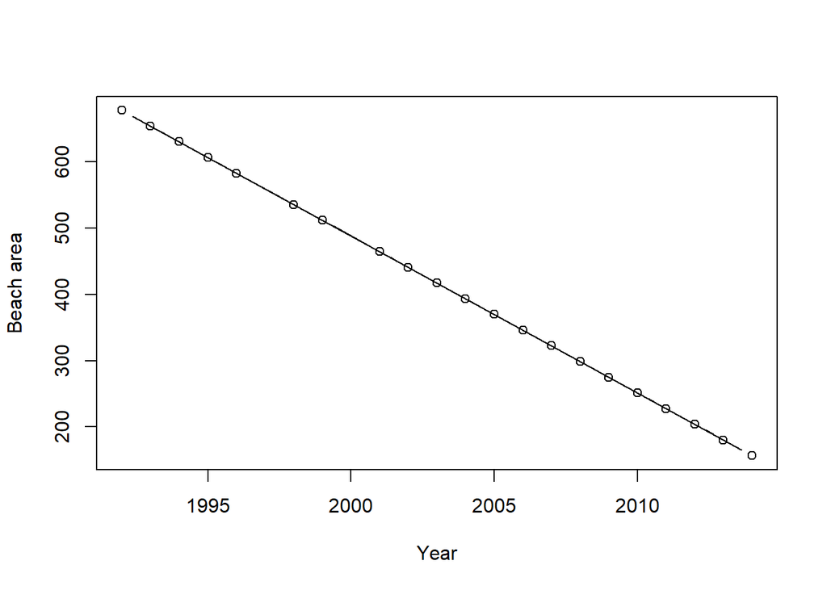

```r
Beacharea_A <- betas[1] + betas[4] * Plover_data$Year
Beacharea_B <- betas[1] + betas[2] + betas[4] * Plover_data$Year
Beacharea_C <- betas[1] + betas[3] + betas[4] * Plover_data$Year

All_Beach <- Beacharea_A + Beacharea_B + Beacharea_C

plot(y = All_Beach, x = Plover_data$Year, xlab = 'Year', ylab = 'Beach area', type = 'b')
```

5. Interpret the rate of beach area change at each of the 3 beaches

```r
#Beach area change for Beach_A
betas[2] + betas[3]
```

```
##  BeachIDB
## -52.80187
```

```r
#Beach area change for Beach_B
betas[2]
```

```
## BeachIDB
## -68.3057
```

```r
#Beach area change for Beach_C
betas[3]
```

```
## BeachIDC
## 15.50383
```